# **Panorama da inflação**

Os principais índices de inflação do Brasil, apontam em outubro de 2004 um avanço da inflação de em média **0.33%**. Com esse resultado, no ano a inflação acumula uma variação média positiva de **6.81%**, e em 12 meses uma variação média acumulada de **8.16%**.

[output not shown]

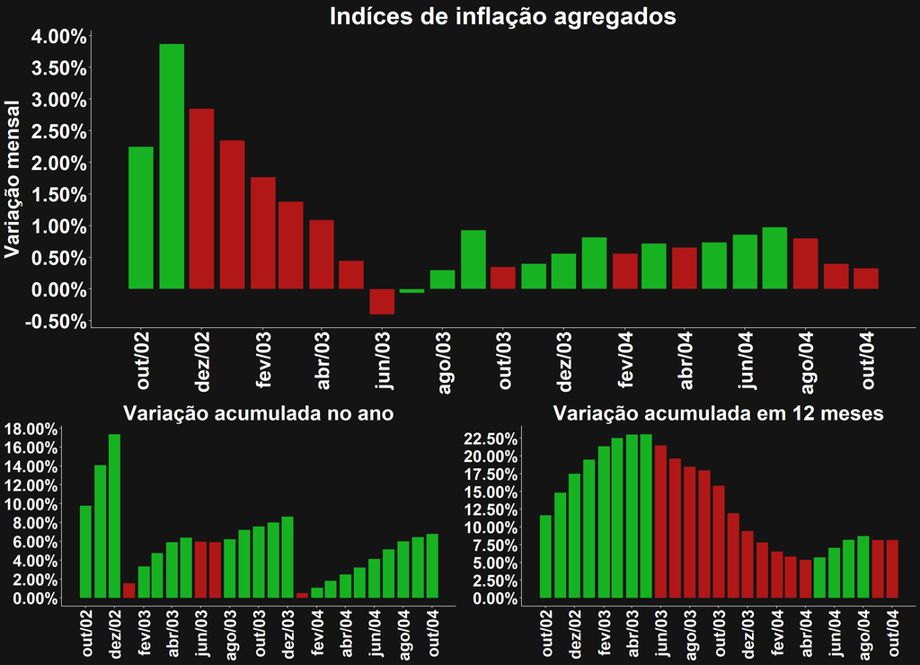

Índices selecionados para a média: IPCA, INPC e IGP-M.

# IPCA

O Indíce de Preços ao Consumidor Amplo (IPCA) variou 0.44% em outubro, valor superior ao mesmo período do ano anterior quando apresentou uma taxa de 0.29%. Com esse resultado o indíce acumula no ano uma variação positiva de 5.95%, e em 12 meses uma variação positiva de 6.86%.

|  | 10/2003 | 09/2004 | 10/2004 |
| --- | --- | --- | --- |
| Variação mensal | 0.29% | 0.33% | 0.44% |
| Variação acumulada no ano | 8.37% | 5.49% | 5.95% |
| Variação acumulada em 12 meses | 13.98% | 6.7% | 6.86% |

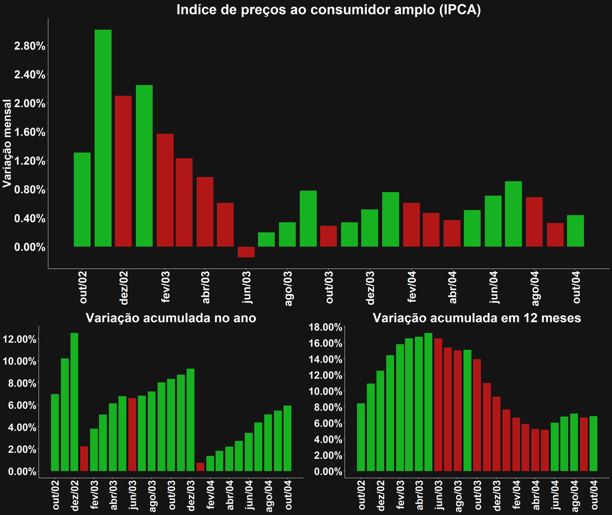

Os grupos que tiveram maior resultado positivo foram Vestuário (1.12%) e Transportes (0.98%), e negativo Alimentação e bebidas (-0.23%) e Educação (-0.08%).

|  | Variação mensal | Variação acumulada no ano | Peso mensal |
| --- | --- | --- | --- |
| Alimentação e bebidas | -0.23% | 3.21% | 22.93% |
| Habitação | 0.46% | 6.22% | 16.61% |
| Artigos de residência | 0.49% | 4.38% | 5.52% |
| Vestuário | 1.12% | 7.15% | 5.26% |
| Transportes | 0.98% | 7.27% | 21.33% |
| Saúde e cuidados pessoais | 0.4% | 6.16% | 10.51% |
| Despesas pessoais | 0.61% | 5.4% | 9.1% |
| Educação | -0.08% | 9.97% | 4.84% |
| Comunicação | 0.69% | 10.83% | 3.9% |

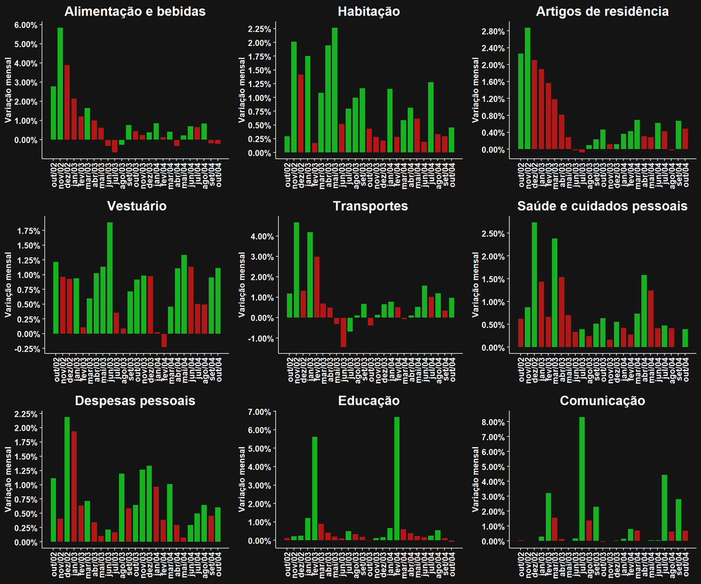

|  | Variação mensal | Variação acumulada no ano | Peso mensal |
| --- | --- | --- | --- |
| Etanol | 5.31% | 15.1% | 0.98% |
| Passagem aérea | 5.03% | 5.33% | 0.59% |
| Gasolina | 1.45% | 6.41% | 4.03% |
| Automóvel novo | 1.29% | 12.25% | 2.98% |

|  | Variação mensal | Variação acumulada no ano | Peso mensal |
| --- | --- | --- | --- |
| Tomate | -16.74% | 42.35% | 0.13% |
| Leite pasteurizado | -2.65% | 12.53% | 1.42% |
| Cebola | -27.87% | 72.19% | 0.08% |
| Ovo de galinha | -7.45% | -7.2% | 0.26% |

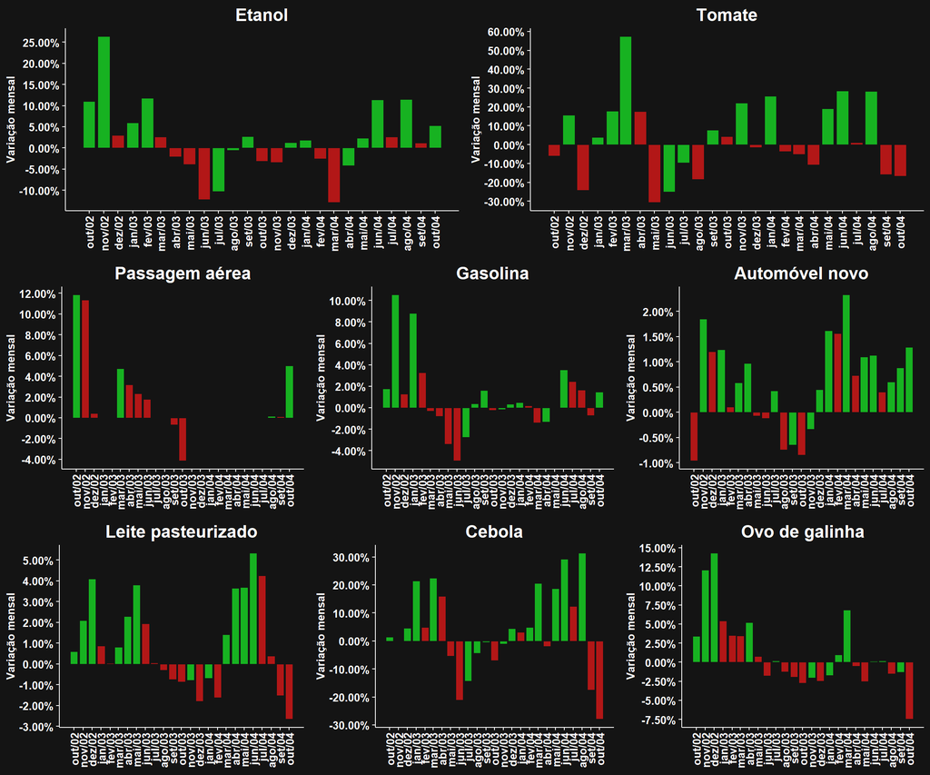

# INPC

|  | 10/2003 | 09/2004 | 10/2004 |
| --- | --- | --- | --- |
| Variação mensal | 0.39% | 0.17% | 0.17% |
| Variação acumulada no ano | 9.39% | 4.59% | 4.77% |
| Variação acumulada em 12 meses | 16.15% | 5.95% | 5.72% |

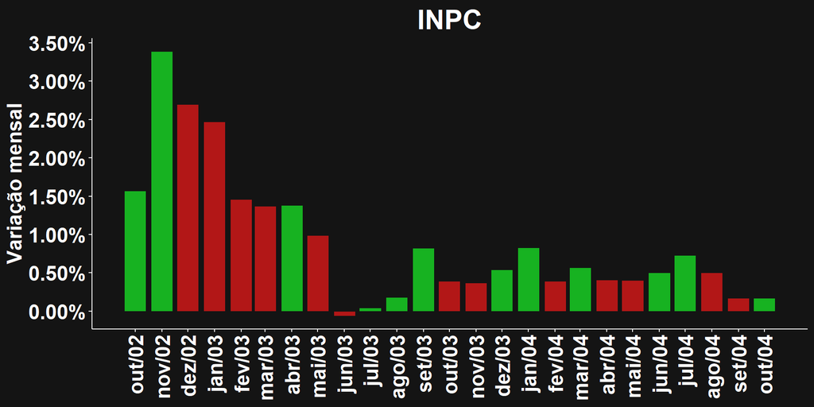

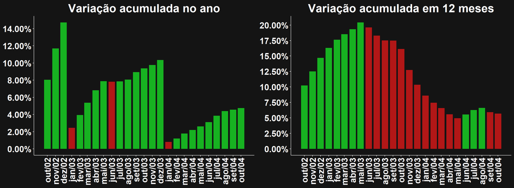

# IGP-M

O Indíce Geral de Preços de Mercado (IGP-M) variou 0.39% em outubro, valor superior ao mesmo período do ano anterior quando apresentou uma taxa de 0.38%. Com esse resultado o indíce acumula no ano uma variação positiva de 9.72%, e em 12 meses uma variação positiva de 11.91%.

|  | 10/2003 | 09/2004 | 10/2004 |
| --- | --- | --- | --- |
| Variação mensal | 0.38% | 0.69% | 0.39% |
| Variação acumulada no ano | 5.07% | 9.3% | 9.72% |
| Variação acumulada em 12 meses | 17.34% | 11.9% | 11.91% |

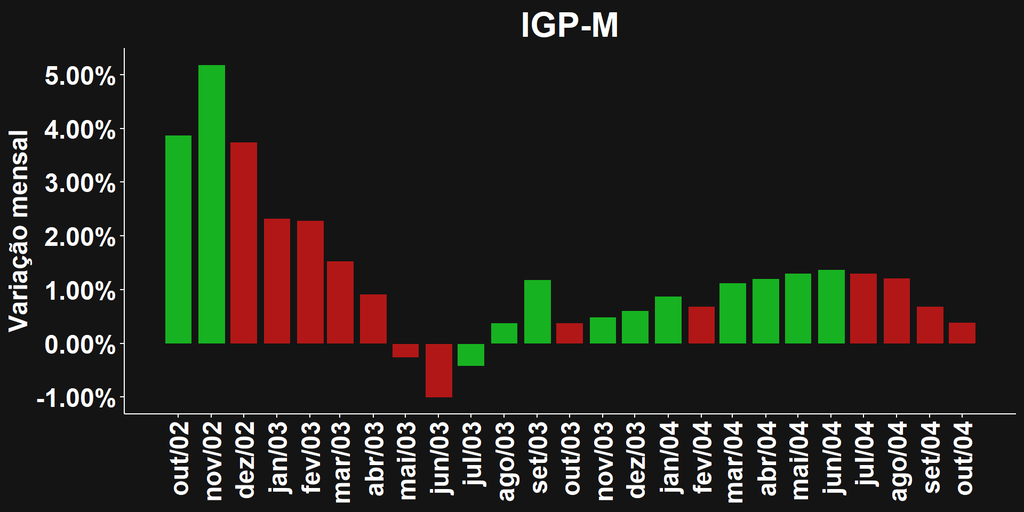

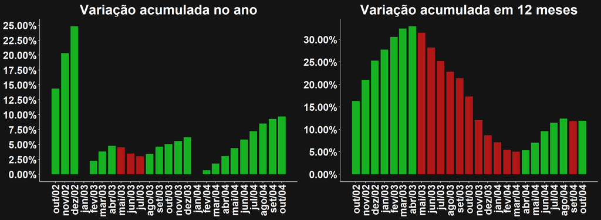

# IGP-DI

O Indíce Geral de Preços - Disponibilidade Interna (IGP-DI) variou 0.53% em outubro, valor superior ao mesmo período do ano anterior quando apresentou uma taxa de 0.44%. Com esse resultado o indíce acumula no ano uma variação positiva de 9.77%, e em 12 meses uma variação positiva de 11.85%.

|  | 10/2003 | 09/2004 | 10/2004 |
| --- | --- | --- | --- |
| Variação mensal | 0.44% | 0.48% | 0.53% |
| Variação acumulada no ano | 4.25% | 9.19% | 9.77% |
| Variação acumulada em 12 meses | 15.78% | 11.74% | 11.85% |

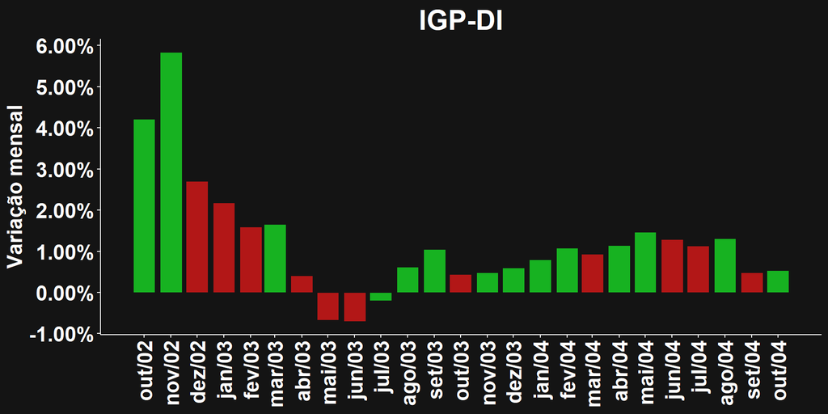

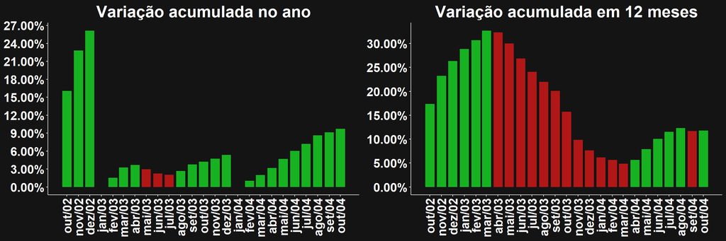

[output not shown]

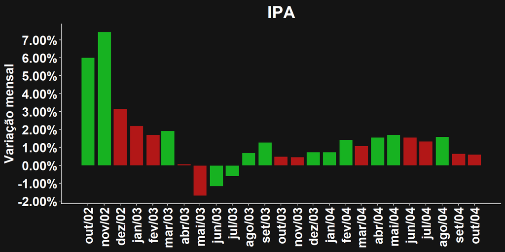

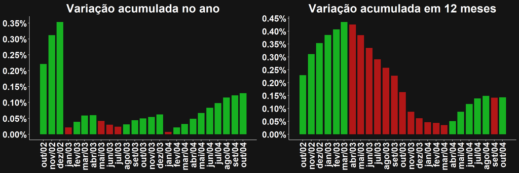

|  | 10/2003 | 09/2004 | 10/2004 |
| --- | --- | --- | --- |
| Variação mensal | 0.21% | 0.01% | 0.1% |
| Variação acumulada no ano | 5.65% | 3.99% | 4.09% |
| Variação acumulada em 12 meses | 13.67% | 6.14% | 6.02% |

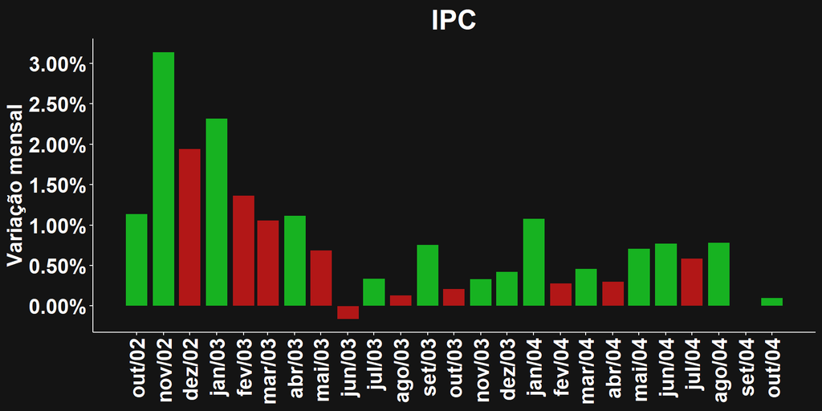

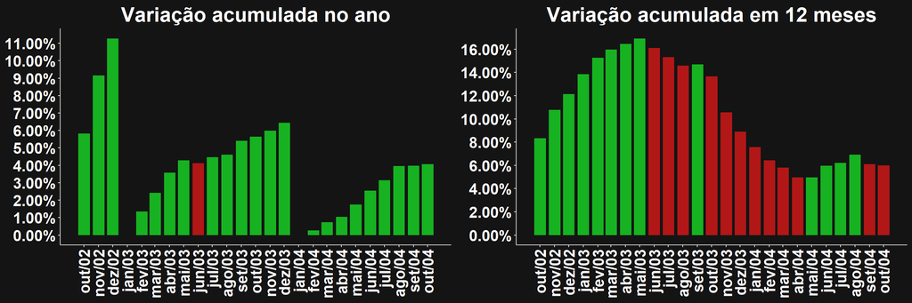

O Indíce Nacional de Custos de Construção (INCC), integrante do IGP-DI com peso de 10%, apresentou variação de 1.19% em outubro, valor superior ao mesmo período do ano anterior quando apresentou uma taxa de 0.65%. Com esse resultado o indíce acumula no ano uma variação positiva de 9.33%, e em 12 meses uma variação positiva de 11%.

|  | 10/2003 | 09/2004 | 10/2004 |
| --- | --- | --- | --- |
| Variação mensal | 0.65% | 0.58% | 1.19% |
| Variação acumulada no ano | 11.39% | 8.04% | 9.33% |
| Variação acumulada em 12 meses | 17.8% | 10.41% | 11% |

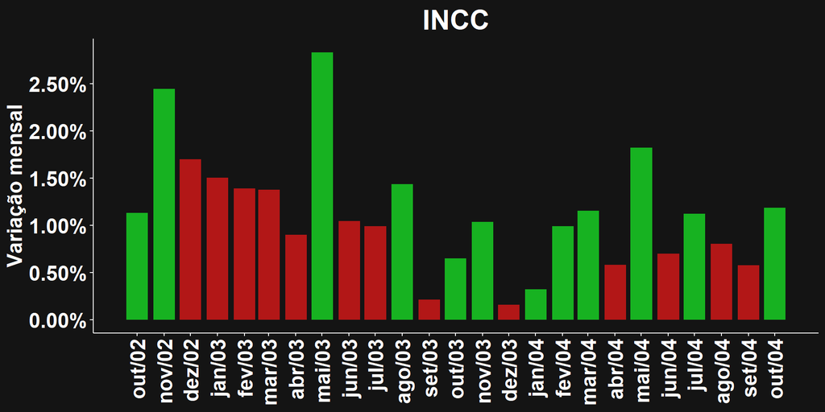

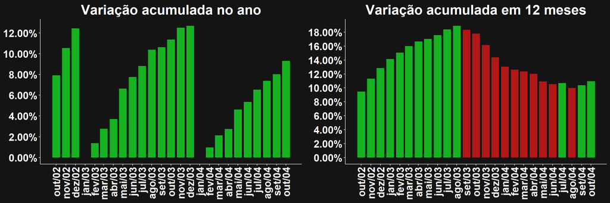

# Estatísticas

As estatísticas descritivas a seguir são feitas com base nos últimos 48 meses, e tem como objetivo possibilitar a avaliação do resultado observado em comparação aos períodos anteriores.

|  | Minimo | 1 Quartil | Mediana | Media | 3 Quartil | Maximo | Desvio Padrão |
| --- | --- | --- | --- | --- | --- | --- | --- |
| IPCA | -0.15% | 0.4% | 0.6% | 0.73% | 0.78% | 3.02% | 0.56% |
| INPC | -0.06% | 0.41% | 0.62% | 0.8% | 0.95% | 3.39% | 0.66% |
| IGP-M | -1% | 0.39% | 0.9% | 1.09% | 1.38% | 5.19% | 1.1% |
| IGP-DI | -0.7% | 0.44% | 0.85% | 1.09% | 1.46% | 5.84% | 1.13% |
| IPA | -1.68% | 0.44% | 1.05% | 1.29% | 1.75% | 7.45% | 1.58% |
| IPC | -0.16% | 0.38% | 0.63% | 0.71% | 0.81% | 3.14% | 0.58% |
| INCC | 0.16% | 0.54% | 0.72% | 0.93% | 1.16% | 2.84% | 0.63% |

Levando em consideração o desvio padrão de cada indíce, proporcionalmente os que mais se afastaram da média foram o IPC, o INPC e o IGP-M.

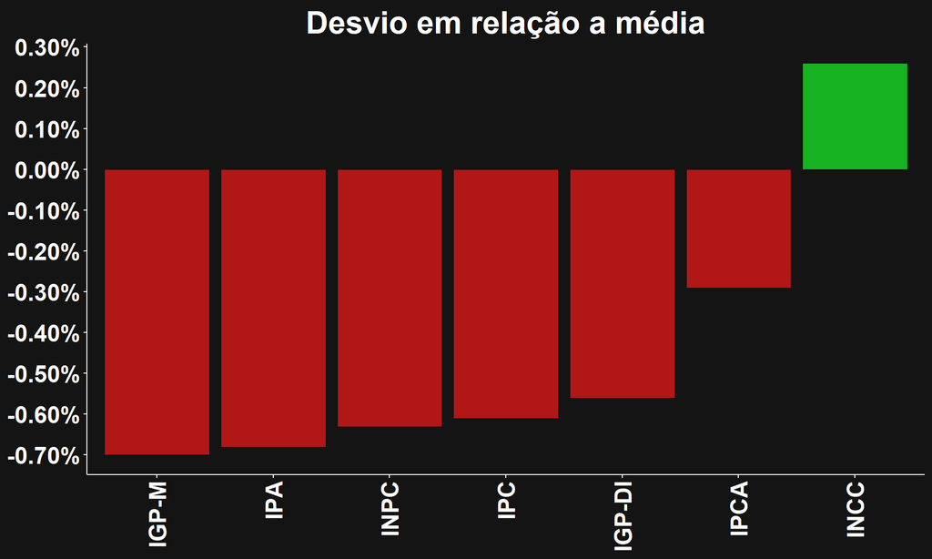

**João Victor Gomes**  
**jvg.santana@gmail.com**  
**[linkedin.com/in/jvictorgomes](https://www.linkedin.com/in/jvictorgomes/)**